# Pixel Binning Methods

Hannah Weller

2017-05-23

- Introduction to `colordistance`
- Pixel Binning Methods
- Color Distance Metrics

## Introduction

This vignette is intended to explain the implications of different binning methods for doing color similarity analyses with the `colordistance` package.

`colordistance` comes with two binning functions: `getImageHist()` and `getKMeanColors()` (or `getHistList()` and `getKMeansList()` for multiple images at once), which categorize colors in a picture using two popular approaches for pixel clustering. Depending on the dataset, the method you choose can have a dramatic impact on your final results. The following explanations should hopefully clarify the differences, and which binning method is most appropriate for a certain dataset.

## Why binning?

[Binning](https://en.wikipedia.org/wiki/Data_binning) is a way of grouping continuous data into categories defined by specific ranges – shoe sizes are a good example of binning (there are certainly more unique foot dimensions than commercially available shoe sizes). In image processing, the first step in measuring color composition of an image is usually to bin all the pixels into a [color histogram](https://en.wikipedia.org/wiki/Color_histogram). This obviously comes at the cost of reducing the variation in the image, but it has a couple of major advantages for image comparisons:

1. It reduces and normalizes the amount of data we need to compare across images.

   If instead of binning, we compared every pixel in an image to a pixel in another image, we would have three major computational problems:
   - We would have to decide which pixels to compare to which other pixels;
   - Even a simple paired comparison would require thousands or millions of calculations per pair of images;
   - And the images almost certainly won’t have the same number of pixels.

   By binning, we can compare apples to apples by comparing bins with the same boundaries from different images. And when we do that, we’re only comparing a finite number bins in one image to the exact same number of bins in another image, which is much quicker than trying to do it for every pixel, especially when much of the pixel-level variation isn’t important for the analysis.
2. It allows us to measure the amount of every color in the image.

   For example, take the following picture of a *Heliconius* butterfly (Meyer (2006)):

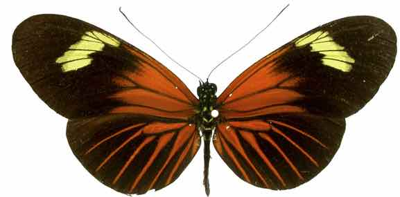

   We could very reasonably say that there are only 3 real colors on this butterfly: black, red, and yellow. But when we plot the individual pixels in the actual image…

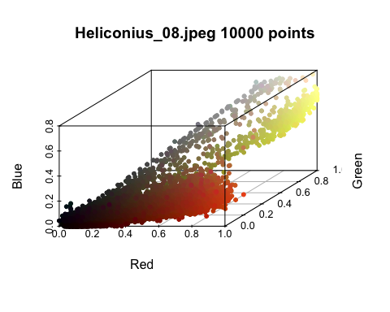

   (See the introduction for more information on the `plotPixels()` function.)

   ```r
   colordistance::plotPixels("Heliconius/Heliconius_08.jpeg", lower=rep(0.8, 3), upper=rep(1, 3))
   ```

   As you might expect, although we can see black, red, and yellow pixels, they’re not all centered in a single place because of noise, lighting variation, and of course actual minor color differences in the animal itself when it was photographed. But if we define a certain range for black pixels in RGB color space, we can just count the proportion of pixels in that range:

   ```
   ## Using 2^3 = 8 total bins
   ```

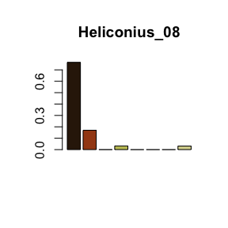

   (For more information in `getImageHist()`, see the ‘Histogram method’ section.)

   ```r
   binnedButterfly <- colordistance::getImageHist("Heliconius/Heliconius_08.jpeg", bins=2,   lower=rep(0.8, 3), upper=rep(1, 3), plotting=T)
   ```

   And we can confidently say that 75% of the pixels in the butterfly were in the “black” range we defined. We’re treating all pixels in that bin as if they’re the same color, but in this case we can say that the simplification doesn’t sacrifice important information. It’s pretty accurate to say that the majority of the butterfly is black; that some of the pixels in the black regions are dark brown or dark grey is not meaningful biological variation for this image. Of course, there are situations where those more subtle color variations *do* matter, in which case you’d need smaller bins to break those pixels up into tighter ranges.

## Histogram method

Both the `getImageHist()` and `getHistList()` functions in `colordistance` use color histograms to bin the pixels in an image.

Each color channel – either red, green and blue (if using RGB) or hue, saturation, and value (if using HSV) – is divided into ranges of equal size. Each combination of ranges from the three channels forms a 3D “bin”. For example, if we chose to divide the blue channel into 2 bins, our ranges in the blue channel would be $0 \leq B \leq 0.5$ and $0.5 < B \leq 1$[^1].

If we did this for each channel, we’d have a total of $2^{3}=8$ bins. A pixel with RGB coordinates of [0.2, 0.8, 0.1] would be in the bin defined by RGB bounds of [0, 0.5], [0.5, 1], and [0, 0.5] – a pixel with the value [0.4, 0.6, 0.4] would be in that same bin. If we divided each channel into 3, the ranges for each one would be 0–0.33, 0.33–0.66 and 0.66–1, for a total of 27 bins, and so on.

The histogram functions take image or folder paths as arguments. The `bins` argument can be a vector of either length 1 or length 3. If it’s a single number, **each channel** is divided into that number of bins, so settings `bins=2` results in 8 bins, `bins=3` in 27, `bins=4` in 64, etc. If you don’t want the same number of bins in each channel, pass a numeric vector of length 3 with the number of bins in each of the R, G, B or H, S, V channels you want, in that order.

```r
par(mfrow=c(2,2))

# Generate histogram using all the default settings (3 bins per channel, get average pixel color in each bin, use RGB instead of HSV)
# See introduction vignette or documentation if lower/upper background pixel arguments are unclear
# Short version: getting rid of any pixels where R, G, and B values are ALL between 0.8 and 1 (aka white)
lower <- rep(0.8, 3)
upper <- rep(1, 3)
defaultHist <- colordistance::getImageHist("Heliconius/Heliconius_08.jpeg", lower=lower, upper=upper, title="3 bins per channel, RGB")
```

```
## Using 3^3 = 27 total bins
```

```r
# We already did 8 bins above, so let's do 1 bin just for sarcasm
oneBin <- colordistance::getImageHist("Heliconius/Heliconius_08.jpeg", lower=lower, upper=upper, bins=1, title="1 bin (pointless but didactic?)")
```

```
## Using 1^3 = 1 total bins
```

```r
# Use 2 red and green bins, but only 1 blue bin
unevenBins <- colordistance::getImageHist("Heliconius/Heliconius_08.jpeg", lower=lower, upper=upper, bins=c(2, 2, 1), title="Non-uniform channel divisions")
```

```
## Using 2*2*1 = 4 bins
```

```
## Using 3^3 = 27 total bins
```

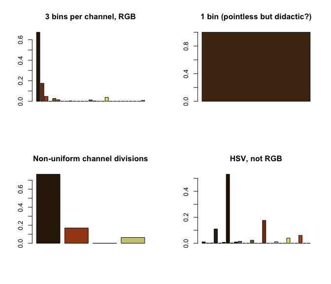

```r
# HSV instead of RGB
hsvBins <- colordistance::getImageHist("Heliconius/Heliconius_08.jpeg", lower=lower, upper=upper, hsv=T, title="HSV, not RGB")
```

In addition to plotting the histogram, the function also returns a dataframe of bin centers and sizes:

```r
defaultHist[1:10, ]
```

```
##            r          g          b          Pct
## 1  0.1640884 0.09956622 0.03378178 6.732649e-01
## 2  0.5106194 0.22951992 0.07119379 1.750520e-01
## 3  0.7399364 0.28977472 0.07697233 4.667173e-02
## 4  0.3186791 0.34200206 0.21692466 2.089450e-04
## 5  0.5201913 0.42134362 0.19521215 2.683294e-02
## 6  0.7492967 0.37061505 0.13377436 1.447219e-02
## 7  0.1666667 0.83333333 0.16666667 0.000000e+00
## 8  0.6656863 0.67549020 0.24215686 4.398843e-05
## 9  0.7333498 0.74124238 0.29925853 2.617312e-03
## 10 0.1666667 0.16666667 0.50000000 0.000000e+00
```

The first three columns of each row are the coordinates in color space of the bin center, and the fourth column is the proportion of pixels in that bin. For example, the first bin, defined by RGB triplet [0.16, 0.10, 0.03], is a very dark brown color, and 6.73e-01 or ~67% of the pixels were assigned to this bin. Two bins with the same set of boundaries may have totally different centers, depending on where the pixels are distributed in that bin. If no pixels are assigned to a bin, its center is defined as the midpoint of the ranges in each channel. So in row 7, the RGB triplet is [0.17, 0.83, 0.17] (a bright green) because the bounds were 0–0.33, 0.67–1, and 0–0.33 and there were no bright green pixels in the image. You can visualize this using `plotClusters()`, or several cluster sets at once using `plotClustersMulti()` (see last section).

If you want to get the bin centers and sizes for a set of images at once, use the `getHistList()` function, which just calls on `getImageHist()` for all of the images it finds in a folder or set of folders.

```r
histList <- colordistance::getHistList("Heliconius/", bins=2, plotting=F)
```

```
## Using 2^3 = 8 total bins
```

```r
# Output of getHistList() is (you guessed it) a list of dataframes as returned by getImageHist()
histList[[1]]
```

```
##           r         g          b          Pct
## 1 0.2496183 0.1779772 0.07175737 0.3149598560
## 2 0.7027810 0.4149608 0.10999870 0.0498903282
## 3 0.4896359 0.5064426 0.41325864 0.0001086372
## 4 0.8776346 0.5702010 0.15412276 0.0940021934
## 5 0.2500000 0.2500000 0.75000000 0.0000000000
## 6 0.5058824 0.4784314 0.50980392 0.0000155196
## 7 0.4941176 0.5450980 0.50588235 0.0000155196
## 8 0.9908927 0.9904837 0.98743203 0.5410286388
```

```r
# and list elements are named for the image they came from
names(histList)
```

```
## [1] "Heliconius_01" "Heliconius_02" "Heliconius_03" "Heliconius_04"
## [5] "Heliconius_05" "Heliconius_06" "Heliconius_07" "Heliconius_08"
```

Unless you have a compelling reason to use k-means instead of the color histogram, I strongly recommend using the histogram binning method.

**Advantages**:

- *Quick.* Because we’re just counting how many pixels fall into each of a set of predetermined bounds, computing the histogram takes very little time. K-means (discussed below) takes longer, because it requires iteratively choosing where to place the cluster centers in an image-specific manner.
- *Consistent comparisons.* Because the bins have the exact same bounds for each image, we can compare the number of pixels in a bin in one image to the number of pixels in the same bin for another image without having to decide if the comparison is a fair one. For example, if you compare color histograms of the French and the Canadian flags, the Canadian flag histogram will have an empty blue bin, but the French flag histogram will have a large blue bin – so we can take into account that one image has a color that is missing from the other image. If you only note the colors that are present, it’s difficult to compare images that have totally different colors.
- *Details remain.* Even if a color takes up a small part of an image, that detail will still show up in the histogram rather than getting swamped by the more dominant colors.
- *Dominant colors aren’t overrepresented.* Conversely, if most of an object is a single color, meaning there’s more variation in that color purely because there are more pixels of that color present, they will still all get grouped together in a single bin. K-means, on the other hand, might assign several different clusters to the same color because so many of the pixels fall into that range.

**Disadvantages**:

- *Artificial distinctions.* If you have a cluster of pixels near a boundary, they will be counted separately. The histograms above are a good example: the yellow pixels usually got stuck into two different bins, one with the darker yellow and one with the more pale yellow, even though the yellow pixels in the pixel plot are relatively continuous, because the distribution crossed the blue boundary at 0.5.
- *Loss of specific color information.* Any binning method will sacrifice color information, but the histogram method treats all pixels within the boundaries of a bin as equivalent. You could have clusters of pixels on opposite sides of a bin which are part of very different color clusters, but which end up treated as a single color which is not actually found on the object because those pixels are averaged out.

  For example, say we had an image of a red and yellow checkerboard, so that all the pixels were either [1, 0, 0] (red) or [1, 1, 0] (yellow). If we only divided the blue channel into bins, then all of the red and yellow pixels would end up in the bin where $B \leq 0.5$, and their average color would be orange – so our color histogram would indicate that we have a completely orange object, rather than a binary red and yellow one. Since the boundaries are arbitrary, they risk not falling along the “natural” clustering boundaries.